# Programming Project #2: Image Quilting

## CS445: Computational Photography - Fall 2019

Ching-Hua Yu (cyu17)

### Part I: Randomly Sampled Texture (10 pts)

The source image to sample

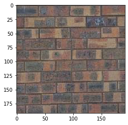

A randomly sampled texture:

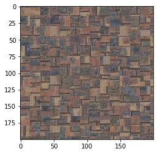

Summary: We use out_size = 200 and patch_size = 15 for all these experiments. Because the patches are selected and pasted randomly without overlaping, The image is composed by regular rectangles.

### Part II: Overlapping Patches (30 pts)

Impletement SSD with linear filters according the the lecture ( https://courses.engr.illinois.edu/cs445/fa2019/lectures/Lecture%2004%20-%20Filtering%20Applications%20-%20CP%20Fall%202019.pdf)

```
small_cost_value= 0.05 patch_size= 15 overlap 5 tolerance factor= 0.1
```

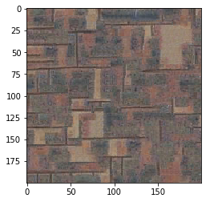

Summary: Because we choose patches by picking one of the best matches according to the overlapping part, the image looks smoother. However the issue is that we replace the overlapping part with the new patch, so the result looks different from the original pattern in the detailed part, and there can still be observable patching edges. In addition, he parameters are somehow sensitive. Particularly, small_cost_value and tolerance factor affect the number of best matching samples that we choose each time. They control the balance between the randomness and the optimization.

### Part III: Seam Finding (20 pts)

```
small_cost_value= 0.05  tolerance factor= 0.1
```

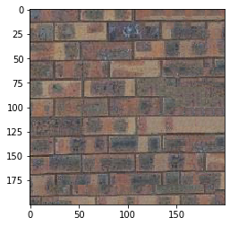

Summary: Here we use a cut function (customized_cut) to decide the seam between overlapping patches. The cut function decided a minimum cost path, where the cost of each pixel on the overlapping area is estimated by the square difference between two overlapping patches. The result looks much close to the original pattern.

To illustrate the patching process, we show the paste of two overlapping patches as well as the min-cost path below. The min-cost path avoid to cut some important features of the backgound image.

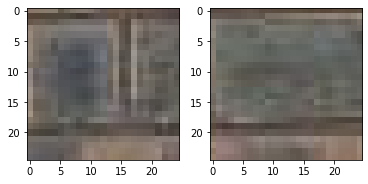

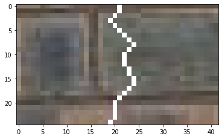

Some more results are shown below: (Image credit: The 3rd one - sand - is belong to Omega from https://omega-products.com/plaster-textures/, and The 4th one - leaf - is belong to Isobel from https://www.pinterest.com/isobel_writes/)

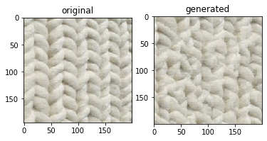

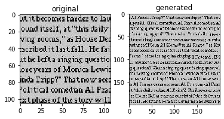

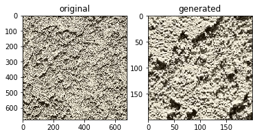

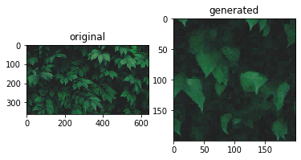

### part IV: Texture Transfer (30 pts)

When matching the patch with the target, I will use the grey scale to estimate the cost because I'll just adapt the output to the color of the sample. (Alternatively, it's like to just use the luminance in LAB.) In addition, the effect can be better if the luminance of the images are balanced first, but it can be an edge improvement except extreme cases.

```
small_cost_value= 0.05 patch_size= 11 overlap= 5 tolerance factor= 0.04 alpha= 0.6
Average size of 47168 samples (not including the first 10)=  927.6971039687924
```

[figure not shown]

Summary: Texture transfer is extended from seam finding-based sampling by adding one more cost that estimates the square difference between the patch and the target image, and tradeoff the two costs with a parameter alpha. By transferring the toast pattern to a (Feynman) face, we get a toast-textured face. In addition, the computation efficiency trade-off of this part can be further checked in the future.

Another example is showed below. By transferring the cutton cloth pattern to a fox image, we get a fox cutton outwear. We can also potentially use LAB to transfer the luminance while using the color from the foreground image as wee.

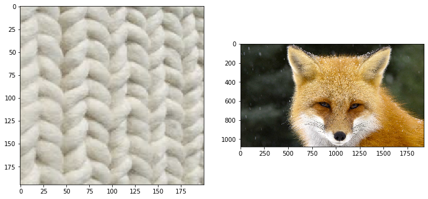

```
small_cost_value= 0.05 patch_size= 11 overlap= 3 tolerance factor= 0.1 alpha= 0.6
Average size of 37449 samples=  482.70949825095465
max matrix value of sample, target, res: 244 255 0.9568627450980393
```

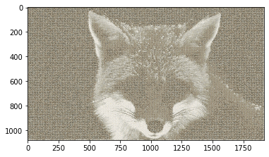

### Bells & Whistles

#### 1.(10 pts) Create and use your own version of cut.m. To get these points, you should create your own implementation without basing it directly on the provided function (you're on the honor code for this one).

The implemented customized_cut(bndcost) can cut a patch on the exact edge which is sometimes useful.

#### 2.(15 pts) Implement the iterative texture transfer method described in the paper. Compare to the non-iterative method for two examples.

In order to get a better visually pleasing result, following Section 3 of the SIGGRAPH 2001 paper by Efros and Freeman, I iterate over the synthesized image several times. According to the paper, the main change from the non-iterative version is that in satisfying the local texture constraint the blocks are matched not just with their neighbor blocks on the overlap regions, but also with whatever was synthesized at this block in the previous iteration. In addition to reducing the block size and increase alpha as said in the paper, I also reduce the overlap size and increase the tolerance factor with each iteration.

[figure not shown]

Summary: With the iterations, the process removes more features in the foreground and fit them with some more detail of the background. It's arguablely more visual pleasing. In addition, When the patch is small, the execution time is long. It might be better to improve to execution time (by e.g., using GPU) and use more iterations.

#### 3.(up to 20 pts) Use a combination of texture transfer and blending to create a face-in-toast image like the one on top. To get full points, you must use some type of blending, such as feathering or Laplacian pyramid blending.

I use the feathering approach as demonstrated in lecture 9. The steps are as the follows: First generate a texture transfer to put the texture (toast) on the target (face). Second genearate a mask of res, centralized in the texture image (toast). Thirs, here I use Gaussian filter to blur the mask. Finally, combine them as the output.

In the first drawing, I combine them by Output = foreground*mask + background*(1-mask). There is still an observable boundary edges even if I make the foreground super blur (using a large kernel size and sigma). In the second drawing, I entend the boundary of the foreground before pasting it to the background so that I can paste a relatively clear face (by a smaller kernel size and sigma) onto the background without clear boundary edges (at least much better than the first drawing).

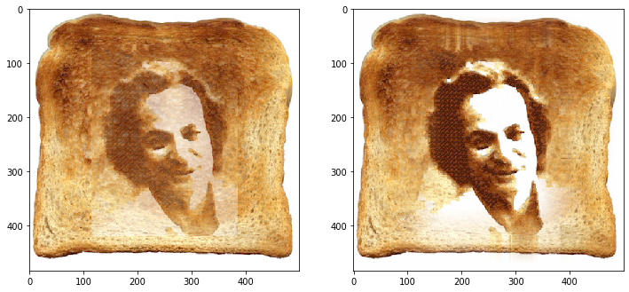

#### 4.(up to 40 pts) Extend your method to fill holes of arbitrary shape for image completion. In this case, patches are drawn from other parts of the target image. For the full 40 pts, you should implement a smart priority function (e.g., similar to Criminisi et al.).

Here I use the laplacian filter to characterize the edge feature of the image, and then use it to estimate the priority of the divided blocks and decide which block should be patched first. The idea is that the more the edge feature appears in a block (not including the hole part), the higher the priority of the block. I have also to mark the block and update the Mask when its patching is done.

[figure not shown]

Summary: I first tried to use an image file with a hole generated by a drawing app. However, the exported file somehow has incomplete marks on the boundary of the hole, which makes it relatively trouble in the hole identification and in the Laplacian process. In general identifying holes by pixel color is unreliable as there can be other pixels in the image of the same color of the hole. As the topic of the proble is not to identify a hole, I turned to decide the hole in the code. The result image respects the priority based on the gradient features and have the iron pole part patched first.